# Final Project - Technical Appendix

Author

Annalise Abraham, Katie Knox, and Hope Levin

Published

October 8, 2025

# Executive Summary

# Limitations and Ethical Considerations

We analyzed from 2010 to 2016, but since then the city has established certain renter’s protections to limit the threat of evictions. More recent data would be helpful to look at to determine which areas are currently experiencing higher eviction rates.

It’s also important to consider which groups are left out of this research. There are many informal evictions that are not captured in court filings. In addition, undocumented immigrants may choose to avoid formal proceedings.

This data and research also needs to be framed appropriately in order to not encourage harmful stereotypes about groups seen as so called ‘problem tenants.’

Lastly, the Eviction Lab only recorded filings and judgments for 2010, 2011, 2012, and 2016. Since then, new renter protections may have altered patterns, so updated data would be necessary to reflect current conditions.

# Policy Problem

Evictions in Philadelphia disproportionately affect lower-income and Black communities, destabilizing families and cultural fabrics, and accelerating processes of gentrification and exclusion. Given that the city’s public agencies have a limited capacity, their ability to understand where and who needs support first is limited. This model clarifies that problem, by showcasing tracts with high judgment counts.

# Who Benefits from this Model

City Agencies - can monitor high-risk tracks and investigate discriminatory patterns in eviction proceedings.

Policy Makers - can create/refine housing policies to reduce inequities and better allocate resources

# Policy Recommendations

Expand the “Good Cause” eviction protection to all tenants.

Focus rental assistance, outreach programs, and community engagement to tracts identified as high-risk by the model.

Investigate repeat eviction fillings and judgments to expose predatory landlords.

Institute affordable housing initiatives and better tenant protections to reduce structural eviction risk.

## Packages

```r
library(sf)
library(tidyverse)
library(tigris)
library(tidycensus)
library(scales)
library(patchwork)
library(here)
library(dplyr)
library(knitr)
library(kableExtra)
library(ggplot2)
library(stringr)
library(units)
library(stargazer)
library(car)
library(caret)
library(lmtest)
options(scipen = 999)

load("data/philadelphia_census.rda")
```

# Phase 1: Eviction Data

## Sourced from The Eviction Lab at Princeton University

The project begins with tract-level eviction data from the Eviction Lab at Princeton University, which provides standardized annual counts of eviction fillings, judgments, and those with threatened status across the US. We filtered the data set to tracts within Philadelphia, which provided us with data from the years 2010, 2011, 2012, and 2016. We then joined that data to the 2016 Census to produce maps of filings and judgments across Philadelphia, which highlighted neighborhood disparities and baselined our understanding of the issue.

```r
evictions <- st_read("./data/tract_proprietary_valid_2000_2018_y2024m12.csv")
phl_evictions <- evictions%>%
  filter(county == "Philadelphia County") %>%
  mutate(
    filings = as.numeric(filings),
    threatened = as.numeric(threatened),
    judgements = as.numeric(judgements)
  )
```

## Load Tract Shapes

```r
tract_shapes <- tracts(
  state = "PA",
  county = "Philadelphia",
  year = 2016,
  cb = TRUE
)
```

## Join Tracts to Evictions

```r
phl_evictions_sf <- tract_shapes %>%
  inner_join(phl_evictions, by = c("GEOID" = "fips"))
```

## Filings Map

```r
filings_map <- phl_evictions_sf%>%
  filter(year==2016)%>%
  mutate(
    filings = as.numeric(filings),   # <-- FIX HERE
    filings_bucket = cut(
      filings,
      breaks = c(0, 10, 25, 50, 100, Inf),
      labels = c("0–10", "11–25", "26–50", "51–100", "100+"),
      right = FALSE
    )
  ) %>%
  ggplot()+
  geom_sf(aes(fill=filings_bucket))+
  theme_void()
```

## Judgments Map

```r
judgements_map <- phl_evictions_sf%>%
  filter(year==2016)%>%
  mutate(
    judgements = as.numeric(judgements),   # <-- FIX HERE
    judgements_bucket = cut(
      judgements,
      breaks = c(0, 10, 25, 50, 100, Inf),
      labels = c("0–10", "11–25", "26–50", "51–100", "100+"),
      right = FALSE
    )
  ) %>%
  ggplot()+
  geom_sf(aes(fill=judgements_bucket))+
  theme_void()
```

Side-by-Side of Maps

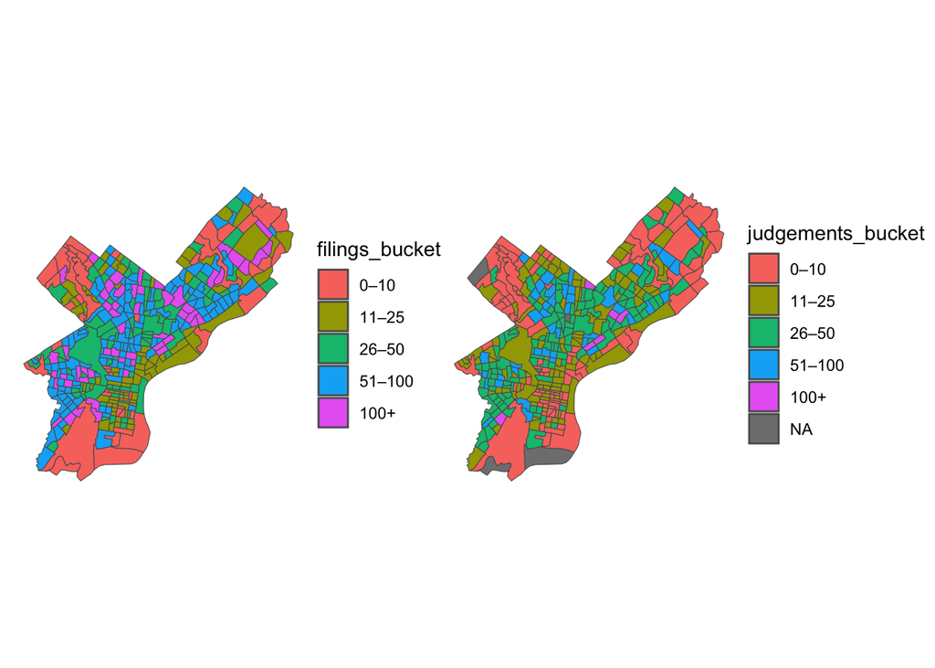

```r
filings_map | judgements_map
```

# Phase 2: Property Data

## Sourced from the City of Philadelphia Office of Property Assessment

To deepen the analysis, we included property data from the Office of Property Assessment. Several filters were applied to remove excess data to a) help select only residential properties, b) remove irregular sales, and c) to reduce the memory use. We then projected everything to a consistent CRS. This data will help explain if variations in housing stock can be linked to eviction outcomes.

```r
property_sales <- st_read("https://github.com/MUSA-5080-Fall-2025/MUSA-5080-Fall-2025/releases/download/v1.0.0/opa_properties_public.csv")
property_sales_filtered <- property_sales %>%
  filter(sale_date >= as.Date("1900-01-01") & sale_date <= as.Date("2025-12-31") ) %>%
  filter(str_detect(category_code_description, "SINGLE FAMILY") |
           str_detect(category_code_description, "MULTI FAMILY") |
           str_detect(category_code_description, "APARTMENTS > 4 UNITS") |
           str_detect(category_code_description, "MIXED USE"))

# Remove Unnecessary Columns to Make Easier to Read
property_sales_filtered <- property_sales_filtered %>%
  select(category_code_description, quality_grade, year_built, total_livable_area, shape)

## Convert to SF and Fix CRS
properties_sf <- property_sales_filtered %>%
  mutate(geometry = st_as_sfc(shape)) %>%
  st_as_sf()

st_crs(properties_sf) <- 2272
properties_sf <- st_transform(properties_sf, 4236)
```

# Phase 3: Census Data

## Sourced from the American Community 5-Year Survey

We then incorporated tract-level data from the 2016 ACS. We chose to filter for population (total, families), racial composition (White and Black), household income (median), and rent burden. The choice to focus on 2016 was intentional, considering the eviction data was last updated that year. From there, we calculated the share of rent-burdened households and percent Black population, and set everything to the same CRS as the property data. With this data, we created a rent burden rate map to further our understanding of Philadelphia’s neighborhoods- North and West Philadelphia had the highest concentrations of rent burdened households.

```r
variables <- c(
  total_population = "B01003_001",
  median_h_income = "B19013_001",
  families = "S1101_C01_002",
  white = "B02001_002",
  black = "B02001_003",
  total_pop = "B02001_001",
  rent_total = "B25070_001",
  rent_30_34 = "B25070_007",
  rent_35_39 = "B25070_008",
  rent_40_49 = "B25070_009",
  rent_50_plus = "B25070_010"
)

census_api_key(Sys.getenv("CENSUS_API_KEY"))
```

```
To install your API key for use in future sessions, run this function with `install = TRUE`.
```

```r
philadelphia <- get_acs(
  geography = "tract",
  county = "Philadelphia",
  state = "PA",
  variables = variables,
  survey = "acs5",
  year = 2016,
  output = "wide",
  geometry = TRUE
) %>%
  mutate (
    rent_burdened = rent_30_34E + rent_35_39E + rent_40_49E + rent_50_plusE,
    rent_burden_rate = rent_burdened / rent_totalE,
    black_percent = blackE / total_popE
  )
```

```
Downloading feature geometry from the Census website.  To cache shapefiles for use in future sessions, set `options(tigris_use_cache = TRUE)`.
```

```
Fetching data by table type ("B/C", "S", "DP") and combining the result.
```

```r
philadelphia <- st_transform(philadelphia, st_crs(properties_sf))
```

## Rent Burden Rate Map

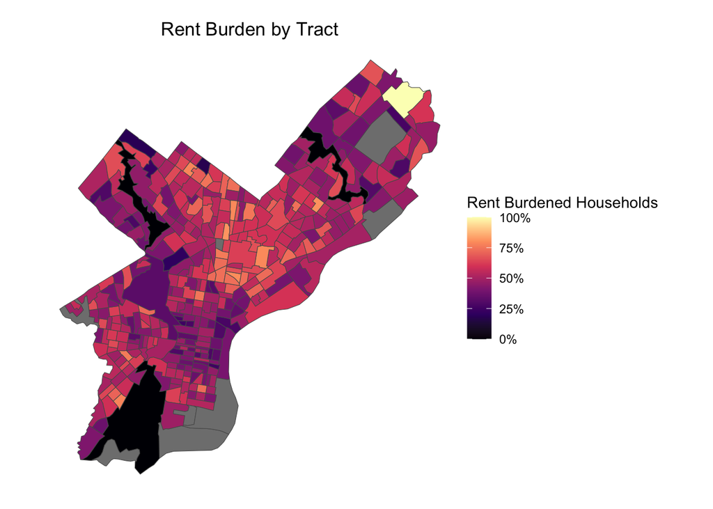

```r
rent_burden_map <- philadelphia %>%
  ggplot() +
  geom_sf(aes(fill = rent_burden_rate)) +
  scale_fill_viridis_c(option = "magma", labels = scales::percent) +
  theme_void() +
  labs(
    title = "Rent Burden by Tract",
    fill = "Rent Burdened Households",
  ) +
  theme(
    plot.title = element_text(hjust = 0.5),
    plot.margin = margin(10,20,10,10))

rent_burden_map
```

# Phase 4: Eviction Rates

```r
evictions_by_tract <- phl_evictions %>%
group_by(fips) %>%
  summarise(
    filings = sum(filings, na.rm = TRUE),
    threatened = sum(threatened, na.rm = TRUE),
    judgements = sum(judgements, na.rm = TRUE),
    year = first(year)
  ) %>%
  mutate(
    pct_judgements_filings = ifelse(filings > 0, judgements / filings, NA),
    pct_judgements_threats = ifelse(threatened > 0, judgements / threatened, NA)
  ) %>%
  rename(GEOID = fips)

philadelphia$GEOID <- as.character(philadelphia$GEOID)

tract_data <- philadelphia %>%
  right_join(st_drop_geometry(evictions_by_tract), by = "GEOID")
```

## Judgment and Filings Ratio Map

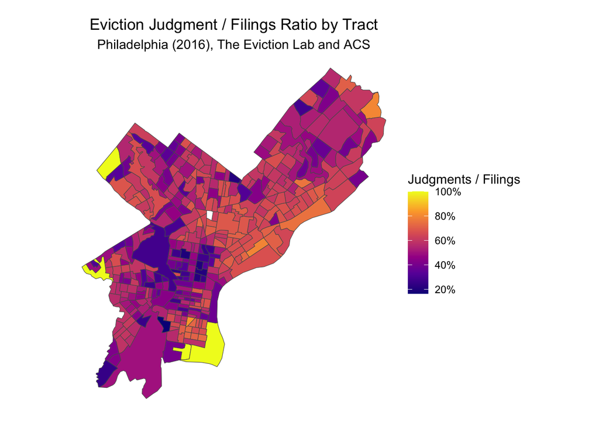

```r
filings_ratio_map <- tract_data %>%
  filter(!is.na(pct_judgements_filings)) %>%
  ggplot() +
  geom_sf(aes(fill = pct_judgements_filings)) +
  scale_fill_viridis_c(option = "plasma", labels = scales::percent) +
  theme_void() +
  labs(
    title = "Eviction Judgment / Filings Ratio by Tract",
    subtitle = "Philadelphia (2016), The Eviction Lab and ACS",
    fill = "Judgments / Filings"
    ) +
  theme(
    plot.title = element_text(hjust = 0.5),
    plot.subtitle = element_text(hjust = 0.5),
    plot.margin = margin(10,20,10,10))

filings_ratio_map
```

## Judgment and Threats Ratio Map

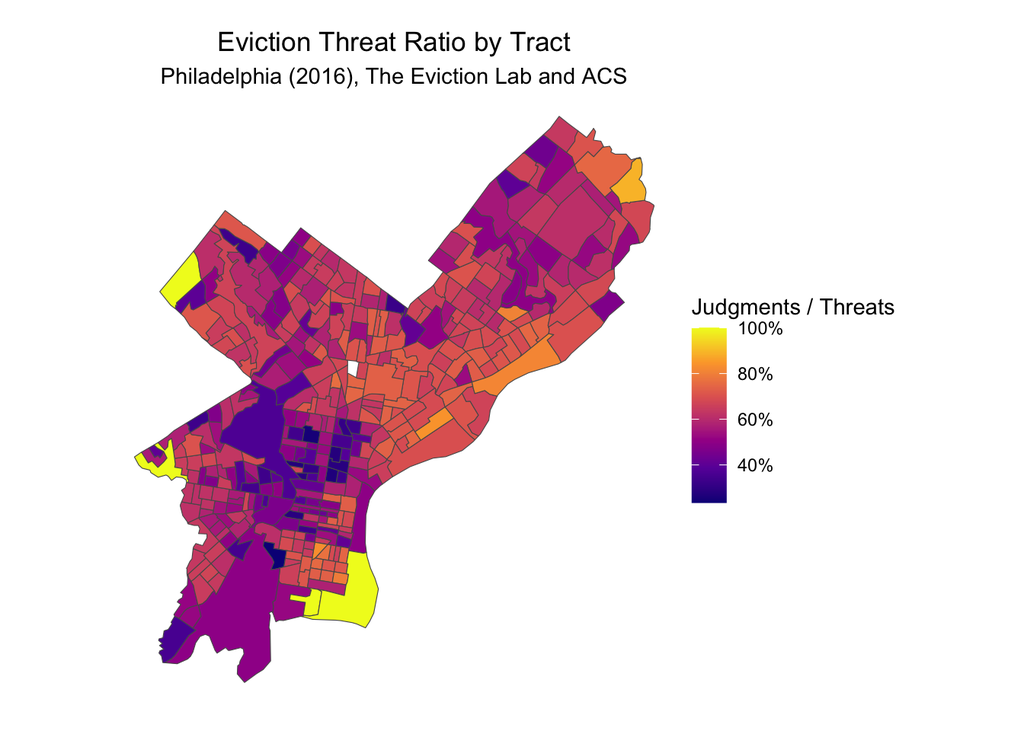

```r
threats_ratio_map <- tract_data %>%
  filter(!is.na(pct_judgements_threats)) %>%
  ggplot() +
  geom_sf(aes(fill = pct_judgements_threats)) +
  scale_fill_viridis_c(option = "plasma", labels = scales::percent) +
  theme_void() +
  labs(
    title = "Eviction Threat Ratio by Tract",
    subtitle = "Philadelphia (2016), The Eviction Lab and ACS",
    fill = "Judgments / Threats"
  ) +
  theme(
    plot.title = element_text(hjust = 0.5),
    plot.subtitle = element_text(hjust = 0.5),
    plot.margin = margin(10,20,10,10))

threats_ratio_map
```

# Phase 5: Joining Property and Census Data

Within this step, we joined data to attach socioeconomic and eviction factors to properties. Doing so creates a unified dataset that captures broader neighborhood conditions, an attempt to better understand Philadelphia’s eviction dynamics at a deeper level. Additionally, these combined features will form the foundation for our modeling.

```r
properties_with_census <- properties_sf %>%
  st_join(tract_data %>%
    select(GEOID,
           filings,
           threatened,
           judgements,
           pct_judgements_filings,
           pct_judgements_threats,
           rent_burden_rate,
           median_h_incomeE,
           blackE,
           total_popE,
           familiesE,
           black_percent)
)

properties_with_tract <- st_join(properties_sf, tract_data %>% select(GEOID),
                                 join = st_within)
```

# Phase 6: Predictive Models

## Data Prep

```r
properties_clean <- properties_with_census %>%
  st_drop_geometry() %>%
  mutate(
    total_livable_area = as.numeric(total_livable_area),
    year_built = as.numeric(year_built),
    rent_burden_rate = as.numeric(rent_burden_rate),
    median_h_incomeE = as.numeric(median_h_incomeE),
    familiesE = as.numeric(familiesE),
    black_percent = as.numeric(black_percent)
  )
```

## Data Aggregation

```r
model_data <- properties_clean %>%
  group_by(GEOID) %>%
  summarise(
    filings = first(filings),
    judgments = first(judgements),
    threatened = first(threatened),
    pct_judgements_filings = first(pct_judgements_filings),
    total_livable_area = median(total_livable_area, na.rm = TRUE),
    median_year_built = median(year_built, na.rm = TRUE),
    quality_grade = names(sort(table(quality_grade), decreasing = TRUE))[1],
    category_code_description = names(sort(table(category_code_description), decreasing = TRUE))[1],
    rent_burden_rate = first(rent_burden_rate),
    median_h_incomeE = first(median_h_incomeE),
    familiesE = first(familiesE),
    black_percent = first(black_percent),
    total_pop = first(total_popE),
  )
```

## Models - Structural, Census, and Binomial

### Structural

```r
structural_model <- lm(pct_judgements_filings ~ category_code_description + quality_grade + median_year_built + total_livable_area,
               data = model_data)
```

### Census Model

```r
census_model <- lm(pct_judgements_filings ~ category_code_description + quality_grade + median_year_built + total_livable_area +
                     rent_burden_rate + median_h_incomeE + familiesE + black_percent,
                   data = model_data)
```

### Binomial Model

```r
binomial_group_model <- glm(cbind(judgments, filings - judgments) ~ category_code_description + quality_grade + median_year_built + total_livable_area +
                              rent_burden_rate + median_h_incomeE + familiesE + black_percent + total_pop,
                         family = binomial,
                         data = model_data)
```

## Model Comparison

```r
stargazer(structural_model, census_model, type = "text",
          star.cutoffs = c(0.05, 0.01, 0.001))
```

```
======================================================================================
                                                     Dependent variable:
                                       -----------------------------------------------
                                                   pct_judgements_filings
                                                 (1)                     (2)
--------------------------------------------------------------------------------------
category_code_descriptionMULTI FAMILY           0.208                   0.165
                                               (0.139)                 (0.129)

category_code_descriptionSINGLE FAMILY          0.070                   0.114
                                               (0.129)                 (0.119)

quality_gradeA-                                 0.173                   0.123
                                               (0.200)                 (0.190)

quality_gradeA+                                7.483**
                                               (2.410)

quality_gradeB                                  0.081                   0.045
                                               (0.131)                 (0.120)

quality_gradeB-                                 0.122                   0.057
                                               (0.145)                 (0.134)

quality_gradeB+                                 0.048                   0.034
                                               (0.134)                 (0.123)

quality_gradeC                                  0.140                   0.115
                                               (0.128)                 (0.119)

quality_gradeC+                                 0.092                   0.084
                                               (0.130)                 (0.120)

median_year_built                              -0.0005                -0.001***
                                              (0.0003)                (0.0003)

total_livable_area                            -0.0001**               -0.0001**
                                              (0.00002)               (0.00002)

rent_burden_rate                                                      0.205***
                                                                       (0.057)

median_h_incomeE                                                      0.00000*
                                                                      (0.00000)

familiesE                                                              0.045**
                                                                       (0.016)

black_percent                                                         -0.088***
                                                                       (0.022)

Constant                                       1.348*                 2.201***
                                               (0.659)                 (0.621)

--------------------------------------------------------------------------------------
Observations                                     376                     373
R2                                              0.116                   0.219
Adjusted R2                                     0.090                   0.189
Residual Std. Error                       0.127 (df = 364)        0.117 (df = 358)
F Statistic                            4.361*** (df = 11; 364) 7.175*** (df = 14; 358)
======================================================================================
Note:                                                    *p<0.05; **p<0.01; ***p<0.001
```

```r
stargazer(
  structural_model, census_model,
  title = "Structural and Census Model Results",
  type = "text",
  dep.var.labels = "Judgments/Filings",
  column.labels = c("Structural", "Census"),
  keep = c("category_code_description", "quality_grade", "total_livable_area", "year_built", "rent_burden_rate", "median_h_incomeE", "familiesE", "black_percent"),
  add.lines = list(
    c("Model Type", "Linear", "Linear")
  ),
  no.space = TRUE,
  digits = 3,
  omit.stat = c("f", "ser")
)
```

```
Structural and Census Model Results
===================================================================
                                           Dependent variable:
                                       ----------------------------
                                            Judgments/Filings
                                         Structural      Census
                                            (1)            (2)
-------------------------------------------------------------------
category_code_descriptionMULTI FAMILY      0.208          0.165
                                          (0.139)        (0.129)
category_code_descriptionSINGLE FAMILY     0.070          0.114
                                          (0.129)        (0.119)
quality_gradeA-                            0.173          0.123
                                          (0.200)        (0.190)
quality_gradeA+                           7.483***
                                          (2.410)
quality_gradeB                             0.081          0.045
                                          (0.131)        (0.120)
quality_gradeB-                            0.122          0.057
                                          (0.145)        (0.134)
quality_gradeB+                            0.048          0.034
                                          (0.134)        (0.123)
quality_gradeC                             0.140          0.115
                                          (0.128)        (0.119)
quality_gradeC+                            0.092          0.084
                                          (0.130)        (0.120)
median_year_built                         -0.0005       -0.001***
                                          (0.0003)      (0.0003)
total_livable_area                       -0.0001***    -0.0001***
                                         (0.00002)      (0.00002)
rent_burden_rate                                        0.205***
                                                         (0.057)
median_h_incomeE                                        0.00000**
                                                        (0.00000)
familiesE                                               0.045***
                                                         (0.016)
black_percent                                           -0.088***
                                                         (0.022)
-------------------------------------------------------------------
Model Type                                 Linear        Linear
Observations                                376            373
R2                                         0.116          0.219
Adjusted R2                                0.090          0.189
===================================================================
Note:                                   *p<0.1; **p<0.05; ***p<0.01
```

# Phase 7: Cross Validation

```r
train_data <- model_data
test_data <- model_data
```

## Fit Binomial Model

```r
binomial_cv_model <- glm(cbind(judgments, filings - judgments) ~ category_code_description + median_year_built + total_livable_area +
                           rent_burden_rate + median_h_incomeE + familiesE + black_percent +total_pop,
                         family = binomial,
                         data = train_data)
```

## Predict on Test Data

```r
test_data$predicted_prob_judgment <- predict(
  binomial_cv_model,
  newdata = test_data,
  type = "response"
)

test_data$predicted_judgments <- test_data$filings * test_data$predicted_prob_judgment
test_data$absolute_error <- abs(test_data$predicted_judgments - test_data$judgments)
mae = mean(test_data$absolute_error,  na.rm = TRUE)

mae
```

```
[1] 23.65577
```

## Absolute Error Map

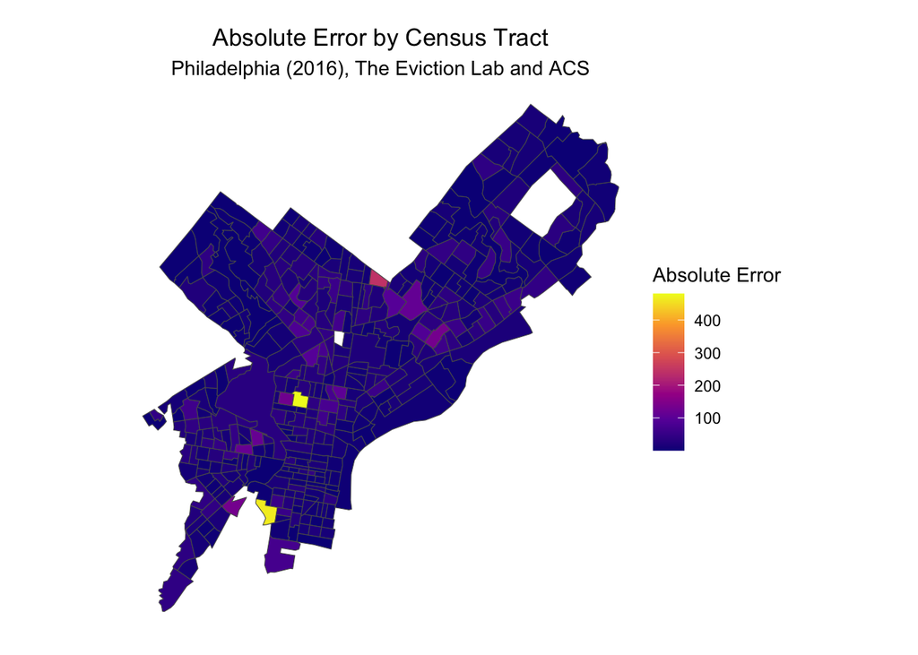

```r
test_data_sf <- test_data %>%
  left_join(
    select(philadelphia, GEOID, geometry),  # keep only GEOID and geometry
    by = "GEOID"
  ) %>%
  st_as_sf()

absolute_error_map <- test_data_sf %>%
  filter(!is.na(absolute_error)) %>%
  ggplot() +
  geom_sf(aes(fill = absolute_error)) +
  scale_fill_viridis_c(option = "plasma") +
  theme_void() +
  labs(
    title = "Absolute Error by Census Tract",
    subtitle = "Philadelphia (2016), The Eviction Lab and ACS",
    fill = "Absolute Error"
  ) +
  theme(
    plot.title = element_text(hjust = 0.5),
    plot.subtitle = element_text(hjust = 0.5),
    plot.margin = margin(10,20,10,10))

absolute_error_map
```

## Absolute Error Map - Without Outliers

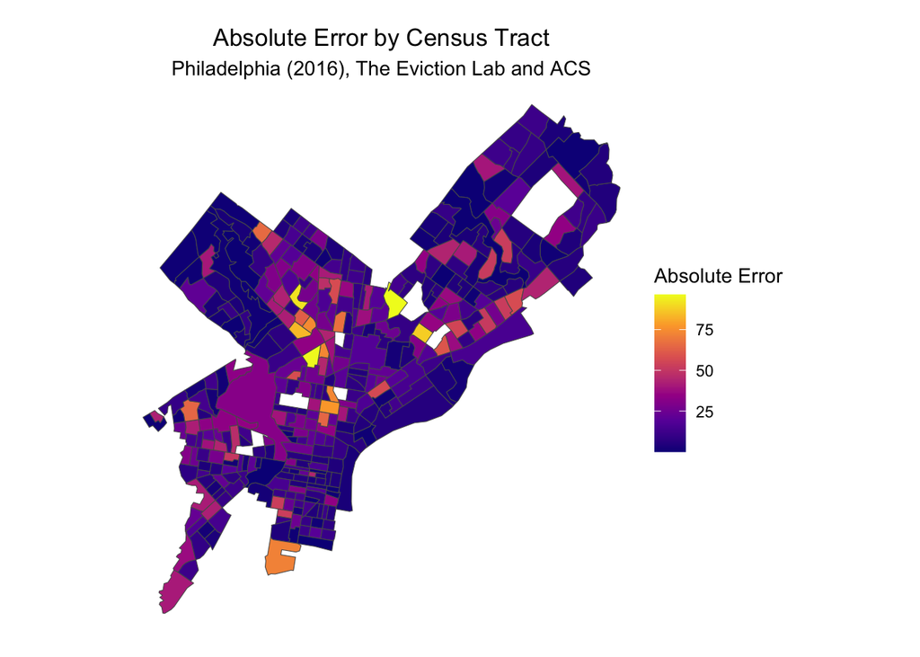

```r
absolute_error_map.2 <- test_data_sf %>%
  filter(!is.na(absolute_error)) %>%
  filter(absolute_error<100)%>%
  ggplot() +
  geom_sf(aes(fill = absolute_error)) +
  scale_fill_viridis_c(option = "plasma") +
  theme_void() +
  labs(
    title = "Absolute Error by Census Tract",
    subtitle = "Philadelphia (2016), The Eviction Lab and ACS",
    fill = "Absolute Error"
  ) +
  theme(
    plot.title = element_text(hjust = 0.5),
    plot.subtitle = element_text(hjust = 0.5),
    plot.margin = margin(10,20,10,10))

absolute_error_map.2
```

## Characteristics of Tracts Worst Predicted

```r
test_data$absolute_error <- unname(test_data$absolute_error)

test_data %>%
  ungroup() %>%  # remove grouping
  slice_max(order_by = absolute_error, n = 10, na_rm = TRUE)%>%
  kable(
    caption = "Top 10 Tracts by Absolute Prediction Error",
    digits = 3,                       # format numeric columns
    align = "c"
  ) %>%
  kable_styling(
    full_width = FALSE,
    position = "center",
    bootstrap_options = c("striped", "hover", "condensed")
  )
```

Top 10 Tracts by Absolute Prediction Error

| GEOID | filings | judgments | threatened | pct_judgements_filings | total_livable_area | median_year_built | quality_grade | category_code_description | rent_burden_rate | median_h_incomeE | familiesE | black_percent | total_pop | predicted_prob_judgment | predicted_judgments | absolute_error |
| --- | --- | --- | --- | --- | --- | --- | --- | --- | --- | --- | --- | --- | --- | --- | --- | --- |
| 42101015200 | 1359 | 267 | 1071 | 0.196 | 1412 | 1915 | C | SINGLE FAMILY | 0.632 | 19105 | 3.20 | 0.926 | 5769 | 0.550 | 747.431 | 480.431 |
| 42101003600 | 1739 | 286 | 1220 | 0.164 | 1120 | 1950 | C | SINGLE FAMILY | 0.416 | 18969 | 2.68 | 0.626 | 7379 | 0.432 | 751.432 | 465.432 |
| 42101027200 | 995 | 213 | 656 | 0.214 | 1168 | 1956 | C | SINGLE FAMILY | 0.514 | 43715 | 2.63 | 0.798 | 5049 | 0.458 | 455.981 | 242.981 |
| 42101030000 | 785 | 533 | 733 | 0.679 | 1260 | 1935 | C | SINGLE FAMILY | 0.493 | 27574 | 2.96 | 0.629 | 7417 | 0.508 | 399.168 | 133.832 |
| 42101006900 | 783 | 203 | 578 | 0.259 | 864 | 1925 | C | SINGLE FAMILY | 0.452 | 15899 | 2.61 | 0.912 | 2542 | 0.427 | 334.538 | 131.538 |
| 42101015102 | 729 | 198 | 579 | 0.272 | 1080 | 1915 | C+ | SINGLE FAMILY | 0.469 | 13750 | 2.26 | 0.922 | 3507 | 0.446 | 324.833 | 126.833 |
| 42101009200 | 649 | 170 | 491 | 0.262 | 1480 | 1925 | C | SINGLE FAMILY | 0.428 | 19028 | 2.85 | 0.694 | 3568 | 0.440 | 285.277 | 115.277 |
| 42101010800 | 593 | 165 | 497 | 0.278 | 1212 | 1925 | C | SINGLE FAMILY | 0.534 | 20861 | 2.63 | 0.881 | 3846 | 0.473 | 280.268 | 115.268 |
| 42101039000 | 703 | 305 | 596 | 0.434 | 1151 | 1940 | C | SINGLE FAMILY | 0.651 | 31063 | 3.41 | 0.644 | 9285 | 0.594 | 417.490 | 112.490 |
| 42101016400 | 414 | 113 | 337 | 0.273 | 1260 | 1920 | C | SINGLE FAMILY | 0.548 | 16222 | 2.95 | 0.454 | 4338 | 0.528 | 218.448 | 105.448 |